# Chap 10. Data visualization in practice

## 10.7.4 Accessing computed variables

To have the areas of these densities be proportional to the size of the groups, we can simply multiply the y-axis values by the size of the group. From the geom_density help file, we see that the functions compute a variable called count that does exactly this. We want this variable to be on the y-axis rather than the density.

In ggplot2, we access these variables by surrounding the name with two dots `..`. We will use the following mapping:

```
aes(x = dollars_per_daym y=..count..) # converting frequency to count
```

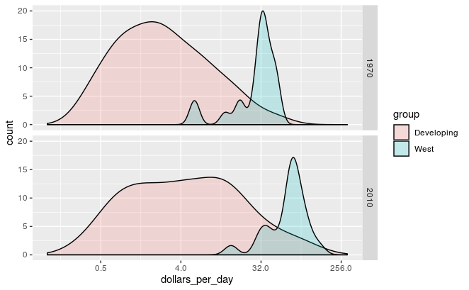

If we want the densities to be smoother, we use the `bw`(bandwidth) argument so that the same bandwidth is used in each density. We selected 0.75 after trying out several values.

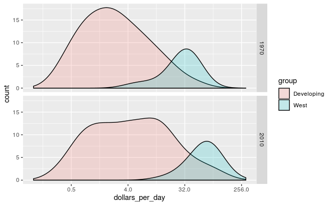

> The distribution of developing world has been changed!
- Let’s explore more detaily.

```
Ignoring unknown parameters: adjust
```

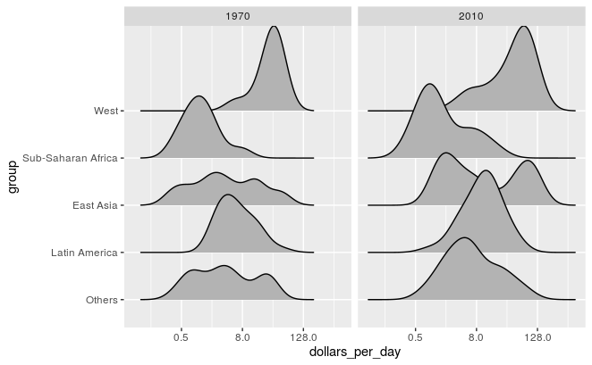

```r
gapminder %>%
  filter(year %in% c(past_year, present_year) & !is.na(dollars_per_day)) %>%
  ggplot(aes(dollars_per_day, group)) +
  scale_x_continuous(trans = "log2") +
  geom_density_ridges(adjust = 1.5) +
  facet_grid(.~year)
```

Another way to achieve this is by stacking the densities on top of each other:

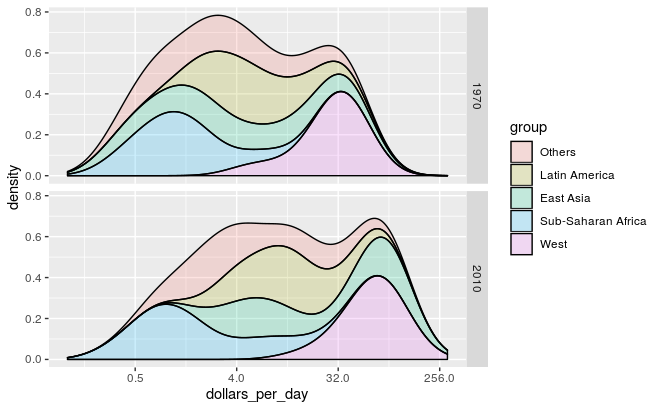

Here we can clearly see how the distributions for East Asia, Latin America and others shift markedly to the right. While Sub-Saharan Africa remains stagnant.

Notice that we order the levels of the group so that the West’s density are plotted first, then Sub-Saharan Africa. Having the two extremes plotted first allows us to see the remaining bimodality better.

## 10.7.5 Weighted densities

As a final point, we note that these distributions weigh every country the same. So if most of the population is improving, but living in a very large country, such as China, we might not appreciate this. We can actually weight the smooth densities using the weight `mapping` argument. The plot then looks like this:

> 17. how to make this plot? how to use `mapping` argument? >> check

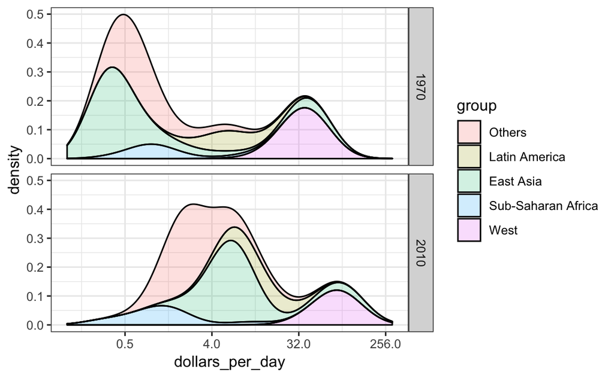

weighted

This particular figure shows very clearly how the income distribution gap is closing with most of the poor remaining in Sub-Saharan Africa.

# 10.8 The ecological fallacy and importance of showing the data

Throughout this section, we have been comparing regions of the world. We have seen that, on average, some regions do better than others. In this section, we focus on describing the importance of variability within the groups when examining the relationship between a country’s infant mortality rates and average income.

We start by comparing these quantities across regions, but before doing this, we define a few more regions:

> 지역을 어떻게 정의하느냐도 매우 중요한 point

| group | income | infant_survival_rate |
| --- | --- | --- |
| Sub-Saharan Africa | 1.759299 | 0.9358607 |
| Southern Asia | 2.070296 | 0.9521295 |
| Pacific Islands | 2.704745 | 0.9560088 |
| Northern Africa | 4.942935 | 0.9703514 |
| Latin America | 13.244228 | 0.9831732 |
| East Asia | 13.439078 | 0.9848303 |
| West | 77.065524 | 0.9951445 |

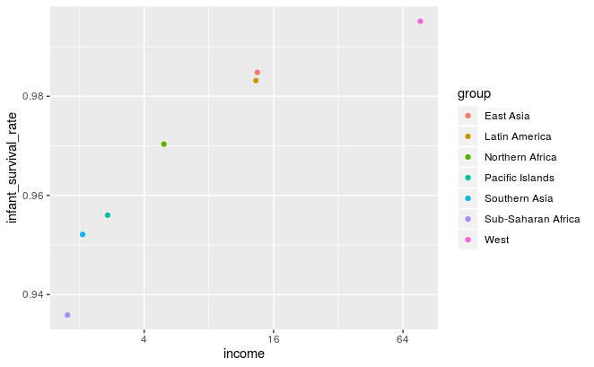

## 10.8.2 Show the data

[figure not shown]

image

```
filter(gapminder, year == 2012) %>%
  mutate(p_infant_mortality = 1-infant_mortality) %>%
#  filter(!is.na(p_infant_mortality) & !is.na(dollars_per_day)) %>%
  ggplot(aes(dollars_per_day, p_infant_mortality, color = group)) +
  geom_point()
```